# Comparing rule sets

Bridget Hegarty, James Riddell

09-08-2022

This Rmarkdown file will compare the viral predictions of multiple pipelines based on the output of CheckV, DeepVirFinder, Kaiju,VIBRANT, VirSorter, and VirSorter2 on multiple training sets of microbial DNA, primarily from NCBI. Created from fungal, viral, bacterial, archeael, protist, and plasmid DNA sequences.

Please reach out to James Riddell (riddell.26@buckeyemail.osu.edu) or Bridget Hegarty (beh53@case.edu) regarding any issues, or open an issue on github.

```r
library(ggplot2)
library(plyr)
library(reshape2)
library(viridis)
library(tidyr)
library(dplyr)
library(readr)
library(data.table)
```

1. For this script’s inputs, the user must merge each viral identification tool output file into one tab-separated file. Replace the filenames with their paths if needed into the variables in the ‘inputs’ chunk.

   General filenames for each tool: Checkv: quality_summary.tsv VIBRANT: VIBRANT_genome_quality_${assembly}.tsv Virsorter: VIRSorter_global-phage-signal.csv Virsorter2: final-viral-score.tsv DeepVirFinder: ${assembly}.fasta_gt2500bp_dvfpred.txt Kaiju: ${assembly}.kaiju.names.out
2. Make sure all fasta headers (assembly, contig) are consistent within and across tools. Chunks for each tool do contain some lines for cleaning up these features, but due to their variability it will be the user’s responsibility to make sure they match across tools.
3. Check each chunk and ensure all columns are accounted for.
4. This script is designed for contigs > 3000 basepairs. It can be modified to be higher or lower, but going lower will greatly increase the size of the dataframe and memory usage.

```r
# dataset name for file organization and outputs for metrics file
dataset_name <- "testing_set"
# checkV
checkV_path <- "../ToolOutput/testing_sets_checkv_output.tsv"
# VIBRANT
vibrant_path <- "../ToolOutput/testing_sets_vibrant_output.tsv"
# DeepVirFinder
dvf_path <- "../ToolOutput/testing_sets_deepvirfinder_output.tsv"
# Virsorter
vs_path <- "../ToolOutput/testing_sets_virsorter_output.tsv"
# Virsorter2
vs2_path <- "../ToolOutput/testing_sets_virsorter2_output.tsv"
# Kaiju
kj_path <- "../ToolOutput/merged.nreuk.kaiju.names.out"
# KB cutoff
KB_CUTOFF <- 3000
```

# All Viral Contigs

## checkV

```r
checkV <- fread(checkV_path,
                sep="\t",
                header = T,
                select = c(
                    'Index',
                    'contig_id',
                    'provirus',
                    'completeness',
                    'contamination',
                    'viral_genes',
                    'host_genes',
                    'gene_count',
                    'contig_length',
                    'checkv_quality'
                    )
                ) %>%
    rename(
        contig = contig_id,
        checkv_provirus = provirus,
        checkv_completeness = completeness,
        checkv_contamination = contamination,
        checkv_viral_genes = viral_genes,
        checkv_host_genes = host_genes,
        checkv_total_genes = gene_count,
        checkv_length = contig_length
        )
checkV$method = 'checkv'
checkV <- separate(checkV, col = contig, into = c("seqtype", "contig"), sep="--")
checkV$contig <- sub("\\.", "_", checkV$contig)
checkV$contig <- sub("\\|", "_", checkV$contig)
```

## VIBRANT

```r
vb_c <- fread(vibrant_path,
              header = T,
              sep = "\t",
              select = c(
                  'Index',
                  'scaffold',
                  'type',
                  'Quality'
                  )
              ) %>%
    rename(
        contig = scaffold,
        vibrant_quality = Quality
        )
vb_c$method <- "vibrant"
vb_c$vibrant_prophage <- "No"
vb_c$vibrant_prophage[grep("_fragment_", vb_c$contig)] <- "Yes"
vb_c <- separate(vb_c, col = contig, into = c("seqtype", "contig"), sep="--")
vb_c$contig <- gsub("_fragment_.*", "", vb_c$contig)
vb_c$contig <- sub("\\.", "_", vb_c$contig)
vb_c <- separate(vb_c, col=contig, into="contig", remove=T, sep = " ")
vb_c <- vb_c[!duplicated(vb_c$contig),]
```

## DeepVirFinder

```r
dvf_c <- fread(dvf_path,
               header = T,
               sep = "\t",
               select = c(
                   'Index',
                   'name',
                   'score',
                   'pvalue'
                   )
               ) %>%
    rename(
        contig = name
        )
dvf_c$contig <- sub("\\.", "_", dvf_c$contig)
dvf_c <- separate(dvf_c, col = contig, into = c("seqtype", "contig"), sep="--")
dvf_c$bh_pvalue <- p.adjust(dvf_c$pvalue, method="BH")
```

## VirSorter

```r
vs_c <- fread(vs_path,
              select = c(
                  'index',
                  'contig',
                  'category'
                  )
              ) %>%
    rename(
        Index = index
        )
vs_c$contig <- sub("VIRSorter_", "", vs_c$contig)
vs_c$contig <- sub("-circular", "", vs_c$contig)
vs_c <- separate(vs_c, col = `contig`, into = c("seqtype", "contig"), sep="--")
vs_c$contig <- sub("\\.", "_", vs_c$contig)
vs_c <- vs_c %>% drop_na(contig)
vs_c <- vs_c[!duplicated(vs_c$contig),]
```

## VirSorter2

```r
vs2_c <- fread(vs2_path,
                    header = T,
                    sep = '\t',
                    select = c(
                        'Index',
                        'seqname',
                        'dsDNAphage',
                        'ssDNA',
                        'max_score',
                        'max_score_group',
                        'hallmark',
                        'viral',
                        'cellular'
                    )
               ) %>%
              separate(
                  col = seqname,
                  into = c("contig", "vs2type"),
                  sep = "\\|\\|",
                  remove = T
                  )
vs2_c$contig <- sub("\\.", "_", vs2_c$contig)
vs2_c <- separate(vs2_c, col = contig, into = c("seqtype", "contig"), sep="--")
vs2_c <- vs2_c[!duplicated(vs2_c$contig),]
```

## Kaiju

```r
kj_c <- read_tsv(kj_path, col_names = T)
kj_c$Contig <- sub("\\.", "_", kj_c$Contig)
kj_c <- separate(kj_c, col = Contig, into = c("seqtype", "contig"), sep="--")
kj_c <- separate(kj_c, col = Name, into = c("Kaiju_Viral","Kingdom"), sep=";")
kj_c$contig <- sub("\\.", "_", kj_c$contig)
```

Quick glimpse of cellular vs viral sequence classification by Kaiju by assembly

```r
table(kj_c$seqtype, kj_c$Kaiju_Viral)
```

```
           cellular organisms Viruses
  archaea                9705      41
  bacteria              59953     164
  fungi                   861     104
  plasmid                4974       3
  protist                 557       2
  virus                  4116    4099
```

## Merging

```r
viruses <- full_join(x=checkV, y=kj_c, by = c("Index", "contig", "seqtype"))
viruses <- full_join(x=viruses, y=dvf_c, by = c("Index", "contig", "seqtype"))
viruses <- full_join(x=viruses, y=vb_c, by = c("Index", "contig", "seqtype"))
viruses <- full_join(x=viruses, y=vs_c, by = c("Index", "contig", "seqtype"))
viruses <- full_join(x=viruses, y=vs2_c, by = c("Index", "contig", "seqtype"))
```

Remove contigs not greater than the basepair length cutoff (3000)

```r
viruses <- viruses %>% filter(checkv_length > KB_CUTOFF)
```

Use the next code chunk to check if any contigs are missing from checkv. If yes, then there is a mix up in contig names since checkv should contain all contig names even if they are identified as non-viral.

```r
v_missing <- viruses[is.na(viruses$checkv_uniq_contig),]
```

calculate percent viral/host/unknown

```r
viruses$percent_host <- viruses$checkv_host_genes/viruses$checkv_total_genes*100
viruses$percent_viral <- viruses$checkv_viral_genes/viruses$checkv_total_genes*100
viruses$percent_unknown <- 100-(viruses$checkv_host_genes+viruses$checkv_viral_genes)/viruses$checkv_total_genes*100
```

get rid of NAs for downstream processing

```r
# checkV
viruses$percent_viral[is.na(viruses$percent_viral)] <- 0
viruses$percent_unknown[is.na(viruses$percent_unknown)] <- 0
# VIBRANT
viruses$vibrant_quality[is.na(viruses$vibrant_quality)] <- 0
# DeepVirFinder
viruses$score[is.na(viruses$score)] <- 0
viruses$bh_pvalue[is.na(viruses$bh_pvalue)] <- 0
# VirSorter2
viruses$viral[is.na(viruses$viral)] <- 0
viruses$hallmark[is.na(viruses$hallmark)] <- 0
#Virsorter
viruses$category[is.na(viruses$category)] <- 0
# Kaiju
viruses$Kaiju_Viral[is.na(viruses$Kaiju_Viral)] <- "unknown"
viruses$Kingdom[is.na(viruses$Kingdom)] <- "unknown"
```

VIBRANT Quality == “High Quality Draft”: +1 Quality == “Medium Quality Draft”: +1 Quality == “Low Quality Draft” & provirus == TRUE: +0.5

Virsorter category == 1,2,4,5: +1 category == 3,6: +0.5

DeepVirFinder: Score >= 0.7: +0.5

Kaiju: Kaiju_viral = “cellular organisms”: -1 Kaiju_viral = “Viruses”: +1

CheckV viral_genes == 0 and host_genes >= 1: keep_score = 0 If 3*viral_genes <= host_genes: keep_score = 0 If length > 50,000 and hallmark == 0: keep_score = 0 If %unknown >= 75: +0.5

You can decide which combination is appropriate for them and only need use the tools appropriate for your data.

```r
getting_viral_set_1 <- function(input_seqs,
                                include_vibrant=FALSE,
                                include_virsorter2=FALSE,
                                include_deepvirfinder=FALSE,
                                include_checkV=FALSE,
                                include_kaiju=FALSE,
                                include_virsorter=FALSE) {

  keep_score <- rep(0, nrow(input_seqs))

  if (include_vibrant) {
    keep_score[input_seqs$vibrant_quality=="high quality draft"] <- keep_score[input_seqs$vibrant_quality=="high quality draft"] + 1
    keep_score[input_seqs$vibrant_quality=="medium quality draft"] <- keep_score[input_seqs$vibrant_quality=="medium quality draft"] + 1
    keep_score[input_seqs$vibrant_quality=="low quality draft" & input_seqs$provirus=="Yes"] <- keep_score[input_seqs$vibrant_quality=="low quality draft" & input_seqs$provirus=="Yes"] + 0.5
  }

  if (include_virsorter2) {
    keep_score[input_seqs$viral>=50] <- keep_score[input_seqs$viral>=50] + 0.5
    keep_score[input_seqs$hallmark>2] <- keep_score[input_seqs$hallmark>2] + 1
    keep_score[input_seqs$viral>=95] <- keep_score[input_seqs$viral>=95] + 1
  }

  if (include_virsorter) {
    keep_score[input_seqs$category==1] <- keep_score[input_seqs$category==1] + 1
    keep_score[input_seqs$category==2] <- keep_score[input_seqs$category==2] + 1
    keep_score[input_seqs$category==3] <- keep_score[input_seqs$category==3] + 0.5
    keep_score[input_seqs$category==4] <- keep_score[input_seqs$category==4] + 1
    keep_score[input_seqs$category==5] <- keep_score[input_seqs$category==5] + 1
    keep_score[input_seqs$category==6] <- keep_score[input_seqs$category==6] + 0.5
  }

  if (include_deepvirfinder) {
    keep_score[input_seqs$score>=0.7] <- keep_score[input_seqs$score>=0.7] + 0.5
#   keep_score[input_seqs$score>=0.9] <- keep_score[input_seqs$score>=0.9] + 0.5
  }
  if (include_kaiju) {
    keep_score[input_seqs$Kaiju_Viral=="cellular organisms"] <- keep_score[input_seqs$Kaiju_Viral=="cellular organisms"] - 1
    keep_score[input_seqs$Kaiju_Viral=="Viruses"] <- keep_score[input_seqs$Kaiju_Viral=="Viruses"] + 1
  }

  if (include_checkV) {
    keep_score[input_seqs$percent_unknown>=75] <- keep_score[input_seqs$percent_unknown>=75] + 0.5
    keep_score[input_seqs$viral_genes==0 & input_seqs$host_genes>=1] <- 0
    keep_score[(input_seqs$viral_genes*3) <= input_seqs$host_genes] <- 0
    keep_score[input_seqs$contig_length>50000 & input_seqs$hallmark==0] <- 0
  }

  return(keep_score)

}
```

this rule set is based on an original set of rules considered for analyzing the drinking water virome. upon analyzing the sequences, many false positive viruses were identified (particularly long sequences with no viral genes) note: checkV is used as a viral sorting tool note: VirFinder was used not DeepVirFinder

```r
getting_viral_set_2 <- function(input_seqs,
                                include_vibrant=FALSE,
                                include_virsorter2=FALSE,
                                include_deepvirfinder=FALSE,
                                include_checkV=FALSE,
                                include_virsorter=FALSE) {

  keep_score <- rep(0, nrow(input_seqs))

  if (include_vibrant) {
    keep_score[input_seqs$vibrant_quality=="high quality draft"] <- keep_score[input_seqs$vibrant_quality=="high quality draft"] + 1
    keep_score[input_seqs$vibrant_quality=="medium quality draft"] <-
      keep_score[input_seqs$vibrant_quality=="medium quality draft"] + 0.5
    keep_score[input_seqs$vibrant_quality=="low quality draft"] <- keep_score[input_seqs$vibrant_quality=="low quality draft"] + 0.3
  }

  if (include_virsorter2) {
    keep_score[input_seqs$viral>=50] <- keep_score[input_seqs$viral>=50] + 0.3
    keep_score[(input_seqs$viral>=50 & input_seqs$host_genes==0) & input_seqs$viral_genes==0] <-
      keep_score[(input_seqs$viral>=50 & input_seqs$host_genes==0) & input_seqs$viral_genes==0] + 0.5
    keep_score[input_seqs$viral>=95] <- keep_score[input_seqs$viral>=95] + 1
    keep_score[input_seqs$hallmark>2] <- keep_score[input_seqs$hallmark>2] + 1
    }

  if (include_virsorter) {
    keep_score[input_seqs$category==1] <- keep_score[input_seqs$category==1] + 1
    keep_score[input_seqs$category==2] <- keep_score[input_seqs$category==2] + 0.5
    keep_score[input_seqs$category==3] <- keep_score[input_seqs$category==3] + 0.3
    keep_score[input_seqs$category==4] <- keep_score[input_seqs$category==4] + 1
    keep_score[input_seqs$category==5] <- keep_score[input_seqs$category==5] + 0.5
    keep_score[input_seqs$category==6] <- keep_score[input_seqs$category==6] + 0.3
  }

  if (include_deepvirfinder) {
    keep_score[input_seqs$score>=0.7] <- keep_score[input_seqs$score>=0.7] + 0.5
    keep_score[input_seqs$score>=0.9] <- keep_score[input_seqs$score>=0.9] + 1
  }

  if (include_checkV) {
    keep_score[input_seqs$checkv_quality=="low"] <- keep_score[input_seqs$checkv_quality=="low"] + 0.3
    keep_score[input_seqs$checkv_quality=="medium"] <- keep_score[input_seqs$checkv_quality=="medium"] + 0.5
    keep_score[input_seqs$checkv_quality=="high"] <- keep_score[input_seqs$checkv_quality=="medium"] + 1

    keep_score[input_seqs$viral_genes==0 & input_seqs$host_genes>1] <- 0
  }

  return(keep_score)

}
```

this is the set of rules used in the drinking water viromes paper note: VirFinder was used not DeepVirFinder

```r
getting_viral_set_3 <- function(input_seqs,
                                include_vibrant=FALSE,
                                include_virsorter2=FALSE,
                                include_deepvirfinder=FALSE,
                                include_checkV=FALSE,
                                include_virsorter=FALSE) {

  keep_score <- rep(0, nrow(input_seqs))

  if (include_vibrant) {
    keep_score[input_seqs$vibrant_quality=="high quality draft"] <- keep_score[input_seqs$vibrant_quality=="high quality draft"] + 1
    keep_score[input_seqs$vibrant_quality=="medium quality draft"] <-
      keep_score[input_seqs$vibrant_quality=="medium quality draft"] + 0.5
    keep_score[input_seqs$vibrant_quality=="low quality draft"] <- keep_score[input_seqs$vibrant_quality=="low quality draft"] + 0.3
  }

  if (include_virsorter2) {
    keep_score[input_seqs$viral>=50] <- keep_score[input_seqs$viral>=50] + 0.3
    keep_score[(input_seqs$viral>=50 & input_seqs$host_genes==0) & input_seqs$viral_genes==0] <-
      keep_score[(input_seqs$viral>=50 & input_seqs$host_genes==0) & input_seqs$viral_genes==0] + 0.5
    keep_score[input_seqs$viral>=95] <- keep_score[input_seqs$viral>=95] + 1
    keep_score[input_seqs$hallmark>2] <- keep_score[input_seqs$hallmark>2] + 1
    }

  if (include_virsorter) {
    keep_score[input_seqs$category==1] <- keep_score[input_seqs$category==1] + 1
    keep_score[input_seqs$category==2] <- keep_score[input_seqs$category==2] + 0.5
    keep_score[input_seqs$category==3] <- keep_score[input_seqs$category==3] + 0.3
    keep_score[input_seqs$category==4] <- keep_score[input_seqs$category==4] + 1
    keep_score[input_seqs$category==5] <- keep_score[input_seqs$category==5] + 0.5
    keep_score[input_seqs$category==6] <- keep_score[input_seqs$category==6] + 0.3
  }

  if (include_deepvirfinder) {
    keep_score[input_seqs$score>=0.7] <- keep_score[input_seqs$score>=0.7] + 0.5
    keep_score[input_seqs$score>=0.9] <- keep_score[input_seqs$score>=0.9] + 1
  }

  if (include_checkV) {
    keep_score[input_seqs$viral_genes==0 & input_seqs$host_genes>=1] <- 0
    keep_score[(input_seqs$viral_genes*3) <= input_seqs$host_genes] <- 0
    keep_score[input_seqs$contig_length>50000 & input_seqs$hallmark==0] <- 0
  }

  return(keep_score)

}
```

# Assessing performance against the “truth”

note that this is only as accurate as the annotations of the input sequences

this function calculates the precision, recall, and F1 score for each pipeline

```r
assess_performance <- function(seqtype, keep_score) {

  truepositive <- rep("not viral", length(seqtype))
  truepositive[seqtype=="virus"] <- "viral"

  #make confusion matrix
  confusion_matrix <- rep("true negative", length(keep_score))
  confusion_matrix[truepositive=="viral" & keep_score<=1] <- "false negative"
  confusion_matrix[truepositive=="viral" & keep_score>=1] <- "true positive"
  confusion_matrix[truepositive=="not viral" & keep_score>=1] <- "false positive"

  precision <- table(confusion_matrix)[4]/(table(confusion_matrix)[4]+table(confusion_matrix)[2])
  recall <- table(confusion_matrix)[4]/(table(confusion_matrix)[4]+table(confusion_matrix)[1])
  F1 <- 2*precision*recall/(precision+recall)

  performance <- c(precision, recall, F1)
  names(performance) <- c("precision", "recall", "F1")

  return(performance)
}
```

combination of tools list

```r
combos_list <- read_csv("combinations_list.csv", col_names = T)
```

this function builds a list of all of the combinations that the user wants to test. In this case, we’re comparing the performance of all unique combinations of the six tools.

```r
build_score_list <- function(input_seqs, combos, pipeline) {
  output <- data.frame(precision=rep(0, nrow(combos)),
                       recall=rep(0, nrow(combos)),
                       F1=rep(0, nrow(combos)))
  for (i in 1:nrow(combos)) {
    if (pipeline==1) {
      keep_score <- getting_viral_set_1(input_seqs, include_vibrant = combos$VIBRANT[i],
                                              include_virsorter = combos$VS[i],
                                              include_virsorter2 = combos$VS2[i],
                                              include_checkV = combos$CheckV[i],
                                              include_kaiju = combos$Kaiju[i],
                                              include_deepvirfinder = combos$DVF[i])
    }
    if (pipeline==2) {
      keep_score <- getting_viral_set_2(input_seqs, include_vibrant = combos$VIBRANT[i],
                                              include_virsorter = combos$VS[i],
                                              include_virsorter2 = combos$VS2[i],
                                              include_checkV = combos$CheckV[i],
                                              include_deepvirfinder = combos$DVF[i])
    }
    if (pipeline==3) {
      keep_score <- getting_viral_set_3(input_seqs, include_vibrant = combos$VIBRANT[i],
                                              include_virsorter = combos$VS[i],
                                              include_virsorter2 = combos$VS2[i],
                                              include_checkV = combos$CheckV[i],
                                              include_deepvirfinder = combos$DVF[i])
    }


    output[i,1:3] <- assess_performance(input_seqs$seqtype, keep_score)

    output$toolcombo[i] <- paste(combos$CheckV[i],combos$DVF[i],
                                 combos$Kaiju[i], combos$VIBRANT[i],
                                 combos$VS[i], combos$VS2[i])
  }

  output[is.na(output)] <- 0

  #return(keep_score)
  return (output)
}
```

## Calculate the performance of each pipeline

first rule set

```r
accuracy_scores <- data.frame(testing_set_index=rep(0, nrow(combos_list)*10),
                      precision=rep(0, nrow(combos_list)*10),
                       recall=rep(0, nrow(combos_list)*10),
                       F1=rep(0, nrow(combos_list)*10))
accuracy_scores <- cbind(testing_set_index=rep(1, nrow(combos_list)),
                              build_score_list(viruses[viruses$Index==1], combos_list, pipeline=1))
for (i in 2:10) {
  accuracy_scores <- rbind(accuracy_scores,
                           cbind(testing_set_index=rep(i, nrow(combos_list)),
                              build_score_list(viruses[viruses$Index==i], combos_list, pipeline=1)))
}
```

```r
library("stringr")
accuracy_scores$numtools <- str_count(accuracy_scores$toolcombo, "1")
accuracy_scores <- accuracy_scores[order(accuracy_scores$numtools, decreasing=F),]
accuracy_scores$toolcombo <- factor(accuracy_scores$toolcombo, levels = unique(accuracy_scores$toolcombo))
accuracy_scores$numtools <- as.factor(accuracy_scores$numtools)
```

## Visualize how the precision, recall, and F1 scores change across pipelines.

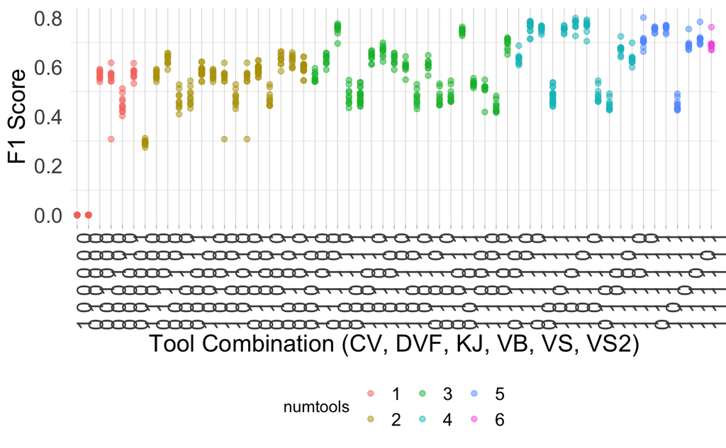

```r
pal <- ggthemes::tableau_color_pal(palette="Tableau 10", type="regular")
p2 <- ggplot(accuracy_scores, aes(x=toolcombo, y=F1,
                                  color=numtools, fill=numtools)) +
  geom_point(alpha=0.5) +
  theme_light() +
  theme(
    panel.grid.major.y = element_blank(),
    panel.border = element_blank(),
    axis.ticks.y = element_blank(),
    legend.position = "bottom",
    axis.text.y=element_text(size=14),
    axis.text.x=element_text(size=14, angle = 90),
    legend.text=element_text(size=12),
    axis.title=element_text(size=16),
  ) +
  xlab("Tool Combination (CV, DVF, KJ, VB, VS, VS2)") +
  ylab("F1 Score")
p2
```

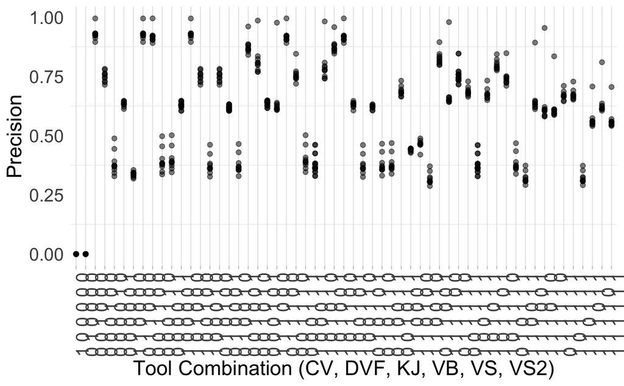

```r
ggplot(accuracy_scores, aes(x=toolcombo, y=precision)) +
  geom_point(alpha=0.5) +
  theme_light() +
  theme(
    panel.grid.major.y = element_blank(),
    panel.border = element_blank(),
    axis.ticks.y = element_blank(),
    legend.position = "bottom",
    axis.text.y=element_text(size=14),
    axis.text.x=element_text(size=14, angle = 90),
    legend.text=element_text(size=12),
    axis.title=element_text(size=16),
  ) +
  xlab("Tool Combination (CV, DVF, KJ, VB, VS, VS2)") +
  ylab("Precision")
```

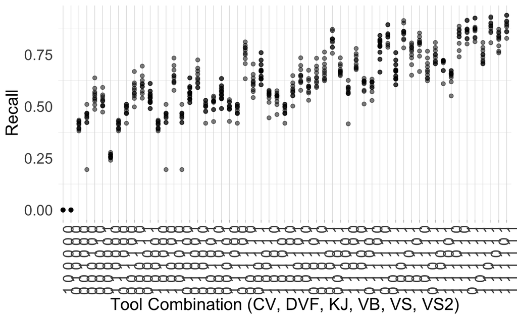

```r
ggplot(accuracy_scores, aes(x=toolcombo, y=recall)) +
  geom_point(alpha=0.5) +
  theme_light() +
  theme(
    panel.grid.major.y = element_blank(),
    panel.border = element_blank(),
    axis.ticks.y = element_blank(),
    legend.position = "bottom",
    axis.text.y=element_text(size=14),
    axis.text.x=element_text(size=14, angle = 90),
    legend.text=element_text(size=12),
    axis.title=element_text(size=16),
  ) +
  xlab("Tool Combination (CV, DVF, KJ, VB, VS, VS2)") +
  ylab("Recall")
```

## Calculate the performance of each pipeline

original rule set from DW paper (didn’t use)

```r
combos_list_3 <- read_csv("combinations_list_3.csv")
```

```r
options(warn=-1)
accuracy_scores_2 <- cbind(testing_set_index=rep(0, nrow(combos_list_3)),
                              build_score_list(viruses[viruses$Index==1], combos_list_3, pipeline=2))
for (i in 2:10) {
  accuracy_scores_2 <- rbind(accuracy_scores_2,
                           cbind(testing_set_index=rep(i, nrow(combos_list_3)),
                              build_score_list(viruses[viruses$Index==i], combos_list_3, pipeline=2)))
}
```

## Visualize how the precision, recall, and F1 scores change across pipelines.

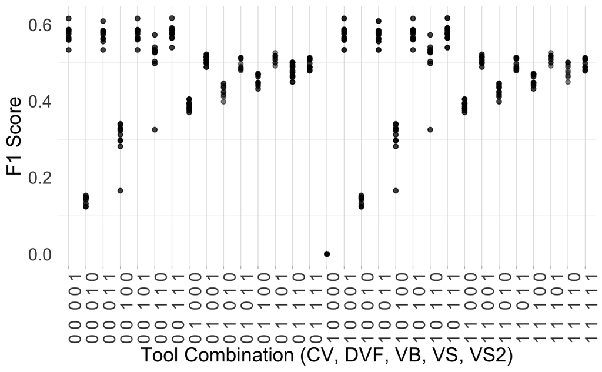

```r
pal <- ggthemes::tableau_color_pal(palette="Tableau 10", type="regular")
ggplot(accuracy_scores_2, aes(x=toolcombo, y=F1)) +
  geom_point(alpha=0.5) +
  theme_light() +
  theme(
    panel.grid.major.y = element_blank(),
    panel.border = element_blank(),
    axis.ticks.y = element_blank(),
    legend.position = "bottom",
    axis.text.y=element_text(size=14),
    axis.text.x=element_text(size=14, angle = 90),
    legend.text=element_text(size=12),
    axis.title=element_text(size=16),
  ) +
  xlab("Tool Combination (CV, DVF, VB, VS, VS2)") +
  ylab("F1 Score")
```

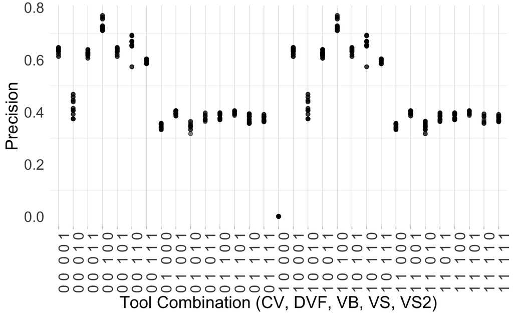

```r
ggplot(accuracy_scores_2, aes(x=toolcombo, y=precision)) +
  geom_point(alpha=0.5) +
  theme_light() +
  theme(
    panel.grid.major.y = element_blank(),
    panel.border = element_blank(),
    axis.ticks.y = element_blank(),
    legend.position = "bottom",
    axis.text.y=element_text(size=14),
    axis.text.x=element_text(size=14, angle = 90),
    legend.text=element_text(size=12),
    axis.title=element_text(size=16),
  ) +
  xlab("Tool Combination (CV, DVF, VB, VS, VS2)") +
  ylab("Precision")
```

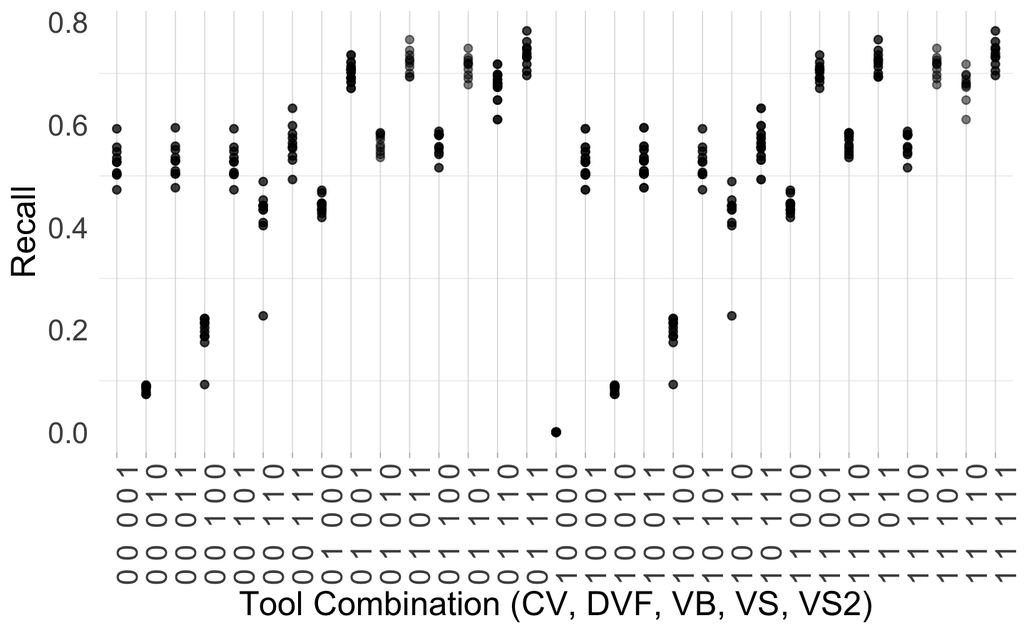

```r
ggplot(accuracy_scores_2, aes(x=toolcombo, y=recall)) +
  geom_point(alpha=0.5) +
  theme_light() +
  theme(
    panel.grid.major.y = element_blank(),
    panel.border = element_blank(),
    axis.ticks.y = element_blank(),
    legend.position = "bottom",
    axis.text.y=element_text(size=14),
    axis.text.x=element_text(size=14, angle = 90),
    legend.text=element_text(size=12),
    axis.title=element_text(size=16),
  ) +
  xlab("Tool Combination (CV, DVF, VB, VS, VS2)") +
  ylab("Recall")
```

## Calculate the performance of each pipeline

rule set from DW paper

```r
combos_list_3 <- read_csv("combinations_list_3.csv")
```

```r
options(warn=-1)
accuracy_scores_3 <- data.frame(testing_set_index=rep(0, nrow(combos_list_3)*10),
                      precision=rep(0, nrow(combos_list_3)*10),
                       recall=rep(0, nrow(combos_list_3)*10),
                       F1=rep(0, nrow(combos_list_3)*10))
accuracy_scores_3 <- cbind(testing_set_index=rep(1, nrow(combos_list_3)),
                              build_score_list(viruses[viruses$Index==1], combos_list_3, pipeline=3))
for (i in 2:10) {
  accuracy_scores_3 <- rbind(accuracy_scores_3,
                           cbind(testing_set_index=rep(i, nrow(combos_list_3)),
                              build_score_list(viruses[viruses$Index==i], combos_list_3, pipeline=3)))
}
```

## Visualize how the precision, recall, and F1 scores change across pipelines.

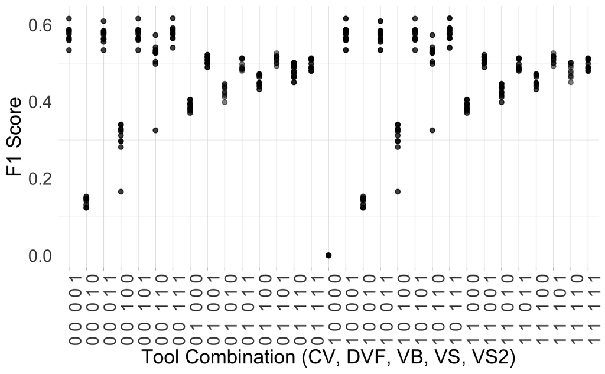

```r
pal <- ggthemes::tableau_color_pal(palette="Tableau 10", type="regular")
p2 <- ggplot(accuracy_scores_3, aes(x=toolcombo, y=F1)) +
  geom_point(alpha=0.5) +
  theme_light() +
  theme(
    panel.grid.major.y = element_blank(),
    panel.border = element_blank(),
    axis.ticks.y = element_blank(),
    legend.position = "bottom",
    axis.text.y=element_text(size=14),
    axis.text.x=element_text(size=14, angle = 90),
    legend.text=element_text(size=12),
    axis.title=element_text(size=16),
  ) +
  xlab("Tool Combination (CV, DVF, VB, VS, VS2)") +
  ylab("F1 Score")
p2
```

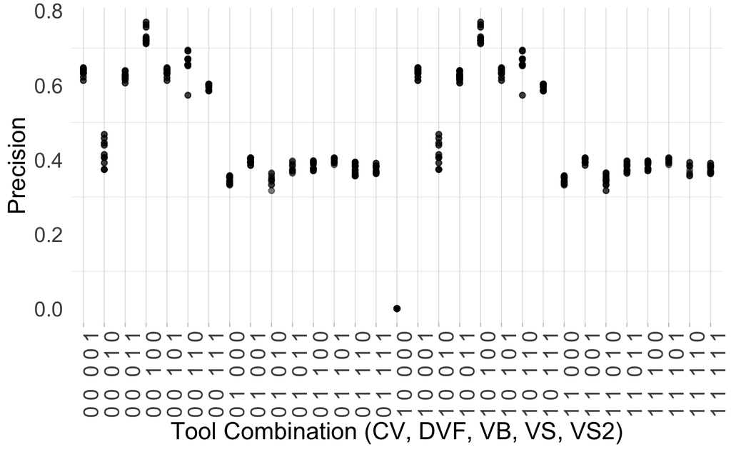

```r
ggplot(accuracy_scores_3, aes(x=toolcombo, y=precision)) +
  geom_point(alpha=0.5) +
  theme_light() +
  theme(
    panel.grid.major.y = element_blank(),
    panel.border = element_blank(),
    axis.ticks.y = element_blank(),
    legend.position = "bottom",
    axis.text.y=element_text(size=14),
    axis.text.x=element_text(size=14, angle = 90),
    legend.text=element_text(size=12),
    axis.title=element_text(size=16),
  ) +
  xlab("Tool Combination (CV, DVF, VB, VS, VS2)") +
  ylab("Precision")
```

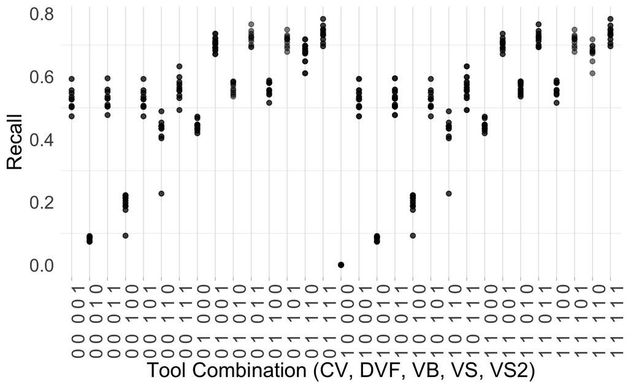

```r
ggplot(accuracy_scores_3, aes(x=toolcombo, y=recall)) +
  geom_point(alpha=0.5) +
  theme_light() +
  theme(
    panel.grid.major.y = element_blank(),
    panel.border = element_blank(),
    axis.ticks.y = element_blank(),
    legend.position = "bottom",
    axis.text.y=element_text(size=14),
    axis.text.x=element_text(size=14, angle = 90),
    legend.text=element_text(size=12),
    axis.title=element_text(size=16),
  ) +
  xlab("Tool Combination (CV, DVF, VB, VS, VS2)") +
  ylab("Recall")
```